# NBA

Andrea Jiménez Zúñiga

10/28/2020

## BASE DE DATOS NBA

```r
library(readr)
library(MASS)
library(carData)
library(car)
library(timeDate)
library(timeSeries)
library(fBasics)
library(akima)
library(gvlma)
nba <- read_csv("nba.csv")
nba <- na.omit(nba)
View(nba)
```

**Voy a cambiar el nombre de algunas variables que me dan problemas a la hora de ejecutar.**

```r
names(nba)[10] = "TS"
names(nba)[13] = "ORB"
names(nba)[14] = "DRB"
names(nba)[15] = "TRB"
names(nba)[16] = "AST"
names(nba)[17] = "STL"
names(nba)[18] = "BLK"
names(nba)[19] = "TDV"
names(nba)[20] = "USG"
names(nba)[11] = "Three_PAr"
names(nba)[24] = "WS48"
names(nba)
```

```
##  [1] "Player"          "Salary"          "NBA_Country"     "NBA_DraftNumber"
##  [5] "Age"             "Tm"              "G"               "MP"
##  [9] "PER"             "TS"              "Three_PAr"       "FTr"
## [13] "ORB"             "DRB"             "TRB"             "AST"
## [17] "STL"             "BLK"             "TDV"             "USG"
## [21] "OWS"             "DWS"             "WS"              "WS48"
## [25] "OBPM"            "DBPM"            "BPM"             "VORP"
```

## MODELO

**Voy a hacer un modelo que incluya todas las variables de mi base de datos. Para ello hago el fitting con lm()**

```r
set.seed(1234)
model <- lm (Salary ~ NBA_DraftNumber+Age+G+MP+ PER+ TS+ Three_PAr+ FTr+
               ORB+ DRB+ TRB+ AST+ STL+ BLK+ TDV+ USG+OWS+DWS+ WS + WS48+
               OBPM+DBPM+ BPM+VORP, data=nba)
summary(model)
```

```
##
## Call:
## lm(formula = Salary ~ NBA_DraftNumber + Age + G + MP + PER +
##     TS + Three_PAr + FTr + ORB + DRB + TRB + AST + STL + BLK +
##     TDV + USG + OWS + DWS + WS + WS48 + OBPM + DBPM + BPM + VORP,
##     data = nba)
##
## Residuals:
##       Min        1Q    Median        3Q       Max
## -15344434  -2975002   -390994   2102049  21682686
##
## Coefficients:
##                 Estimate Std. Error t value Pr(>|t|)
## (Intercept)     -2250339    4899140  -0.459    0.646
## NBA_DraftNumber   -60481      12755  -4.742 2.83e-06 ***
## Age               516821      56511   9.146  < 2e-16 ***
## G                -154411      24983  -6.181 1.41e-09 ***
## MP                  5657       1083   5.224 2.67e-07 ***
## PER              -355059     280566  -1.266    0.206
## TS              -2162767    5149052  -0.420    0.675
## Three_PAr       -3458209    2357905  -1.467    0.143
## FTr              -158470     886960  -0.179    0.858
## ORB             -1055234     902929  -1.169    0.243
## DRB              -855005     893502  -0.957    0.339
## TRB              2006676    1788697   1.122    0.263
## AST               -19606      47542  -0.412    0.680
## STL              -196551     421995  -0.466    0.642
## BLK               110238     318223   0.346    0.729
## TDV                 4208      52692   0.080    0.936
## USG               169431     104692   1.618    0.106
## OWS             -1271685    4493110  -0.283    0.777
## DWS             -1735775    4518854  -0.384    0.701
## WS               1827796    4498896   0.406    0.685
## WS48             1914677   11797052   0.162    0.871
## OBPM             1878971    4744860   0.396    0.692
## DBPM             1438902    4660878   0.309    0.758
## BPM             -1295954    4678340  -0.277    0.782
## VORP              629465     633799   0.993    0.321
## ---
## Signif. codes:  0 '***' 0.001 '**' 0.01 '*' 0.05 '.' 0.1 ' ' 1
##
## Residual standard error: 5103000 on 458 degrees of freedom
## Multiple R-squared:  0.5479, Adjusted R-squared:  0.5242
## F-statistic: 23.13 on 24 and 458 DF,  p-value: < 2.2e-16
```

## SELECCIÓN DE VARIABLES

### AIC

Genero un nuevo modelo con AIC para que me de las variables que son mas significativas.

```r
stepAIC(model, direction = "backward")
```

```
## Start:  AIC=14944.57
## Salary ~ NBA_DraftNumber + Age + G + MP + PER + TS + Three_PAr +
##     FTr + ORB + DRB + TRB + AST + STL + BLK + TDV + USG + OWS +
##     DWS + WS + WS48 + OBPM + DBPM + BPM + VORP
##
##                   Df  Sum of Sq        RSS   AIC
## - TDV              1 1.6611e+11 1.1928e+16 14943
## - WS48             1 6.8601e+11 1.1928e+16 14943
## - FTr              1 8.3134e+11 1.1928e+16 14943
## - BPM              1 1.9984e+12 1.1930e+16 14943
## - OWS              1 2.0862e+12 1.1930e+16 14943
## - DBPM             1 2.4821e+12 1.1930e+16 14943
## - BLK              1 3.1253e+12 1.1931e+16 14943
## - DWS              1 3.8425e+12 1.1931e+16 14943
## - OBPM             1 4.0840e+12 1.1932e+16 14943
## - WS               1 4.2986e+12 1.1932e+16 14943
## - AST              1 4.4292e+12 1.1932e+16 14943
## - TS               1 4.5947e+12 1.1932e+16 14943
## - STL              1 5.6497e+12 1.1933e+16 14943
## - DRB              1 2.3847e+13 1.1951e+16 14944
## - VORP             1 2.5688e+13 1.1953e+16 14944
## - TRB              1 3.2777e+13 1.1960e+16 14944
## - ORB              1 3.5570e+13 1.1963e+16 14944
## - PER              1 4.1708e+13 1.1969e+16 14944
## <none>                          1.1928e+16 14945
## - Three_PAr        1 5.6019e+13 1.1984e+16 14945
## - USG              1 6.8209e+13 1.1996e+16 14945
## - NBA_DraftNumber  1 5.8559e+14 1.2513e+16 14966
## - MP               1 7.1068e+14 1.2638e+16 14970
## - G                1 9.9486e+14 1.2922e+16 14981
## - Age              1 2.1782e+15 1.4106e+16 15024
##
## Step:  AIC=14942.58
## Salary ~ NBA_DraftNumber + Age + G + MP + PER + TS + Three_PAr +
##     FTr + ORB + DRB + TRB + AST + STL + BLK + USG + OWS + DWS +
##     WS + WS48 + OBPM + DBPM + BPM + VORP
##
##                   Df  Sum of Sq        RSS   AIC
## - FTr              1 7.9833e+11 1.1929e+16 14941
## - WS48             1 8.4655e+11 1.1929e+16 14941
```

[output cut: 294 more lines]

```
##     TRB + USG + WS + OBPM
##
##                   Df  Sum of Sq        RSS   AIC
## <none>                          1.2043e+16 14923
## - Three_PAr        1 8.1804e+13 1.2124e+16 14924
## - ORB              1 1.2227e+14 1.2165e+16 14926
## - PER              1 1.3025e+14 1.2173e+16 14926
## - OBPM             1 1.3257e+14 1.2175e+16 14926
## - USG              1 1.3897e+14 1.2182e+16 14927
## - TRB              1 2.6687e+14 1.2310e+16 14932
## - NBA_DraftNumber  1 6.5783e+14 1.2700e+16 14947
## - WS               1 6.9027e+14 1.2733e+16 14948
## - MP               1 9.6191e+14 1.3005e+16 14958
## - G                1 1.3853e+15 1.3428e+16 14974
## - Age              1 2.2154e+15 1.4258e+16 15003
```

```
##
## Call:
## lm(formula = Salary ~ NBA_DraftNumber + Age + G + MP + PER +
##     Three_PAr + ORB + TRB + USG + WS + OBPM, data = nba)
##
## Coefficients:
##     (Intercept)  NBA_DraftNumber              Age                G
##        -3893333           -62168           511716          -159255
##              MP              PER        Three_PAr              ORB
##            5204          -320540         -3013992          -201694
##             TRB              USG               WS             OBPM
##          333889           130873           845245           550301
```

```r
model2 <- lm(formula = Salary ~ NBA_DraftNumber + Age + G + MP + PER +
                 Three_PAr + ORB + TRB + USG + WS + OBPM, data = nba)
summary(model2)
```

```
##
## Call:
## lm(formula = Salary ~ NBA_DraftNumber + Age + G + MP + PER +
##     Three_PAr + ORB + TRB + USG + WS + OBPM, data = nba)
##
## Residuals:
##       Min        1Q    Median        3Q       Max
## -15532214  -3017494   -365840   2303991  21608017
##
## Coefficients:
##                   Estimate Std. Error t value Pr(>|t|)
## (Intercept)     -3893332.9  2785355.5  -1.398  0.16284
## NBA_DraftNumber   -62168.3    12256.4  -5.072 5.66e-07 ***
## Age               511716.1    54973.9   9.308  < 2e-16 ***
## G                -159255.3    21635.8  -7.361 8.21e-13 ***
## MP                  5204.0      848.4   6.134 1.82e-09 ***
## PER              -320540.0   142016.8  -2.257  0.02446 *
## Three_PAr       -3013991.7  1685020.0  -1.789  0.07431 .
## ORB              -201694.2    92231.2  -2.187  0.02925 *
## TRB               333889.2   103347.8   3.231  0.00132 **
## USG               130872.7    56136.5   2.331  0.02016 *
## WS                845245.2   162676.1   5.196 3.04e-07 ***
## OBPM              550301.3   241673.6   2.277  0.02323 *
## ---
## Signif. codes:  0 '***' 0.001 '**' 0.01 '*' 0.05 '.' 0.1 ' ' 1
##
## Residual standard error: 5057000 on 471 degrees of freedom
## Multiple R-squared:  0.5435, Adjusted R-squared:  0.5329
## F-statistic: 50.98 on 11 and 471 DF,  p-value: < 2.2e-16
```

Hago otro stepAIC para ver si puedo eliminar algunas de las variables del modelo 2.

```r
stepAIC(model2, direction = "backward")
```

```
## Start:  AIC=14923.2
## Salary ~ NBA_DraftNumber + Age + G + MP + PER + Three_PAr + ORB +
##     TRB + USG + WS + OBPM
##
##                   Df  Sum of Sq        RSS   AIC
## <none>                          1.2043e+16 14923
## - Three_PAr        1 8.1804e+13 1.2124e+16 14924
## - ORB              1 1.2227e+14 1.2165e+16 14926
## - PER              1 1.3025e+14 1.2173e+16 14926
## - OBPM             1 1.3257e+14 1.2175e+16 14926
## - USG              1 1.3897e+14 1.2182e+16 14927
## - TRB              1 2.6687e+14 1.2310e+16 14932
## - NBA_DraftNumber  1 6.5783e+14 1.2700e+16 14947
## - WS               1 6.9027e+14 1.2733e+16 14948
## - MP               1 9.6191e+14 1.3005e+16 14958
## - G                1 1.3853e+15 1.3428e+16 14974
## - Age              1 2.2154e+15 1.4258e+16 15003
```

```
##
## Call:
## lm(formula = Salary ~ NBA_DraftNumber + Age + G + MP + PER +
##     Three_PAr + ORB + TRB + USG + WS + OBPM, data = nba)
##
## Coefficients:
##     (Intercept)  NBA_DraftNumber              Age                G
##        -3893333           -62168           511716          -159255
##              MP              PER        Three_PAr              ORB
##            5204          -320540         -3013992          -201694
##             TRB              USG               WS             OBPM
##          333889           130873           845245           550301
```

Aparece que no puedo eliminar las variables poco significativas del modelo 2.

### ANOVA

Voy a comparar ambos modelos con anova.

```r
anova(model, model2)
```

```
## Analysis of Variance Table
##
## Model 1: Salary ~ NBA_DraftNumber + Age + G + MP + PER + TS + Three_PAr +
##     FTr + ORB + DRB + TRB + AST + STL + BLK + TDV + USG + OWS +
##     DWS + WS + WS48 + OBPM + DBPM + BPM + VORP
## Model 2: Salary ~ NBA_DraftNumber + Age + G + MP + PER + Three_PAr + ORB +
##     TRB + USG + WS + OBPM
##   Res.Df        RSS  Df   Sum of Sq      F Pr(>F)
## 1    458 1.1928e+16
## 2    471 1.2043e+16 -13 -1.1504e+14 0.3398 0.9854
```

Sale con un p = 0.9854. No es significativo el test, por lo que no aportan a la predicción lineal por lo que se justifica que elimine esas variables de mi modelo inicial.

## DETECCION DE LA MULTICOLINEALIDAD:

```r
vif(model2)
```

```
## NBA_DraftNumber             Age               G              MP             PER
##        1.262696        1.040844        5.394048        8.895257       29.081095
##       Three_PAr             ORB             TRB             USG              WS
##        2.755505        3.366046        4.884538        2.016768        3.568490
##            OBPM
##       27.843542
```

```r
sqrt(vif(model2))>2
```

```
## NBA_DraftNumber             Age               G              MP             PER
##           FALSE           FALSE            TRUE            TRUE            TRUE
##       Three_PAr             ORB             TRB             USG              WS
##           FALSE           FALSE            TRUE           FALSE           FALSE
##            OBPM
##            TRUE
```

```r
model3 <- lm(formula = Salary ~ NBA_DraftNumber + Age + G+
              Three_PAr + ORB + TRB + USG + WS + OBPM , data = nba)
summary(model3)
```

```
##
## Call:
## lm(formula = Salary ~ NBA_DraftNumber + Age + G + Three_PAr +
##     ORB + TRB + USG + WS + OBPM, data = nba)
##
## Residuals:
##       Min        1Q    Median        3Q       Max
## -15718763  -3237174   -476591   2291904  21784544
##
## Coefficients:
##                 Estimate Std. Error t value Pr(>|t|)
## (Intercept)     -9067896    2272616  -3.990 7.65e-05 ***
## NBA_DraftNumber   -74902      12677  -5.909 6.61e-09 ***
## Age               506275      57353   8.827  < 2e-16 ***
## G                 -42704      13271  -3.218  0.00138 **
## Three_PAr         -64346    1373344  -0.047  0.96265
## ORB              -191298      94213  -2.030  0.04287 *
## TRB               117868      87748   1.343  0.17983
## USG               151380      46254   3.273  0.00114 **
## WS               1487095     136388  10.903  < 2e-16 ***
## OBPM              -20898      55565  -0.376  0.70701
## ---
## Signif. codes:  0 '***' 0.001 '**' 0.01 '*' 0.05 '.' 0.1 ' ' 1
##
## Residual standard error: 5293000 on 473 degrees of freedom
## Multiple R-squared:  0.4977, Adjusted R-squared:  0.4881
## F-statistic: 52.07 on 9 and 473 DF,  p-value: < 2.2e-16
```

```r
vif(model3)
```

```
## NBA_DraftNumber             Age               G       Three_PAr             ORB
##        1.232766        1.033890        1.852140        1.670474        3.205359
##             TRB             USG              WS            OBPM
##        3.213590        1.249566        2.289186        1.343259
```

```r
sqrt(vif(model3))>2
```

```
## NBA_DraftNumber             Age               G       Three_PAr             ORB
##           FALSE           FALSE           FALSE           FALSE           FALSE
##             TRB             USG              WS            OBPM
##           FALSE           FALSE           FALSE           FALSE
```

Muestro el intervalo de confianza para cada uno de los coeficientes parciales de regresión:

```r
confint(model3)
```

```
##                        2.5 %      97.5 %
## (Intercept)     -13533568.46 -4602223.25
## NBA_DraftNumber    -99811.99   -49992.29
## Age                393577.20   618973.26
## G                  -68781.35   -16625.98
## Three_PAr        -2762956.53  2634263.63
## ORB               -376426.25    -6170.36
## TRB                -54556.74   290293.62
## USG                 60490.32   242268.80
## WS                1219092.66  1755096.53
## OBPM              -130083.07    88286.85
```

#### Semilla 1234:

Voy a establecer una semilla mediante set.seed(1234), para un total de n = 10 con los datos de la muestra.

```r
set.seed(1234)
n <- 10
muestra <- sample(1:nrow(nba), size = n, replace= FALSE)
nba10 <- nba[muestra,]
nba10
```

```
## # A tibble: 10 x 28
##    Player Salary NBA_Country NBA_DraftNumber   Age Tm        G    MP   PER    TS
##    <chr>   <dbl> <chr>                 <dbl> <dbl> <chr> <dbl> <dbl> <dbl> <dbl>
##  1 Jason… 5.22e6 USA                      20    31 WAS      31   276   8.2 0.444
##  2 Gary … 2.55e6 USA                      19    23 DEN      65  2265  16.6 0.599
##  3 D'Ang… 5.56e6 USA                       2    21 BRK      44  1124  15.5 0.506
##  4 Reggi… 1.60e7 USA                      24    27 DET      41  1084  15.5 0.516
##  5 Paul … 1.31e6 Germany                  48    23 CHI      54   824   5.2 0.444
##  6 Davis… 1.31e6 Latvia                   42    25 SAS      74  1067  14.2 0.587
##  7 Nigel… 9.22e4 USA                      62    23 TOT       6    60   2.4 0.362
##  8 Chris… 2.46e7 USA                       4    32 HOU      55  1753  24.3 0.601
##  9 Dario… 2.42e6 Croatia                  12    23 PHI      74  2229  16.1 0.587
## 10 DeAnd… 1.58e6 USA                      53    29 TOT      55   711   6.2 0.485
## # … with 18 more variables: Three_PAr <dbl>, FTr <dbl>, ORB <dbl>, DRB <dbl>,
## #   TRB <dbl>, AST <dbl>, STL <dbl>, BLK <dbl>, TDV <dbl>, USG <dbl>,
## #   OWS <dbl>, DWS <dbl>, WS <dbl>, WS48 <dbl>, OBPM <dbl>, DBPM <dbl>,
## #   BPM <dbl>, VORP <dbl>
```

```r
predmuestra <- predict( model3, newdata = nba10)
predmuestra
```

```
##           1           2           3           4           5           6
##  6905623.91  9608482.15  5208569.71  7729736.36 -1135652.55  5011297.33
##           7           8           9          10
##    51237.63 22986617.20 11298239.90  1891441.35
```

## ANÁLISIS DE LA NORMALIDAD:

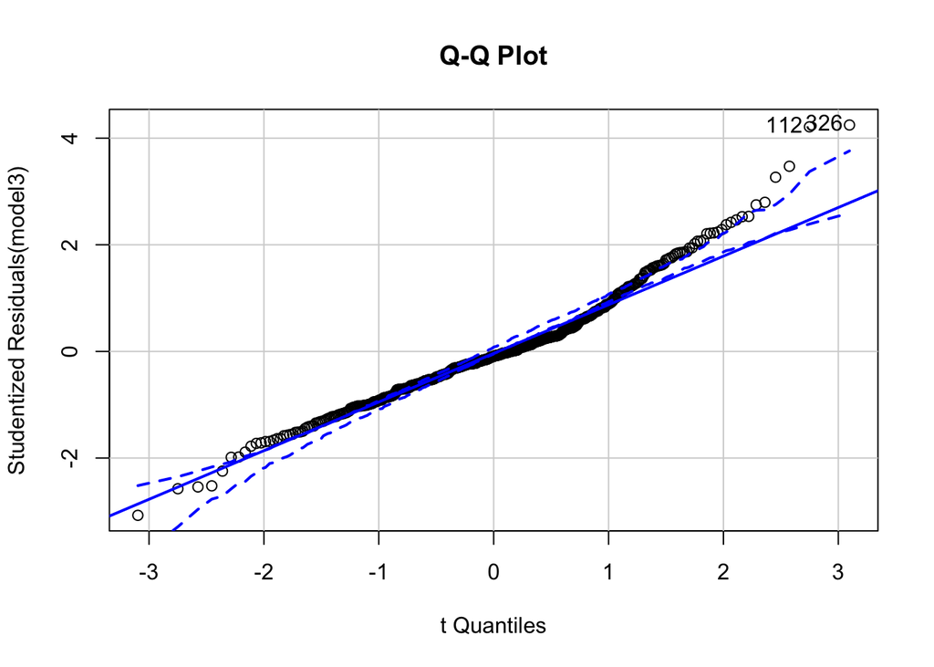

```
## [1] 112 326
```

Me indica los valores atípicos más importantes que no te generan normalidad, por lo que hay que ver por qué. En este caso son el 326 y 112 .

## HISTOGRAMA + DENSIDAD + NORMAL + RUG

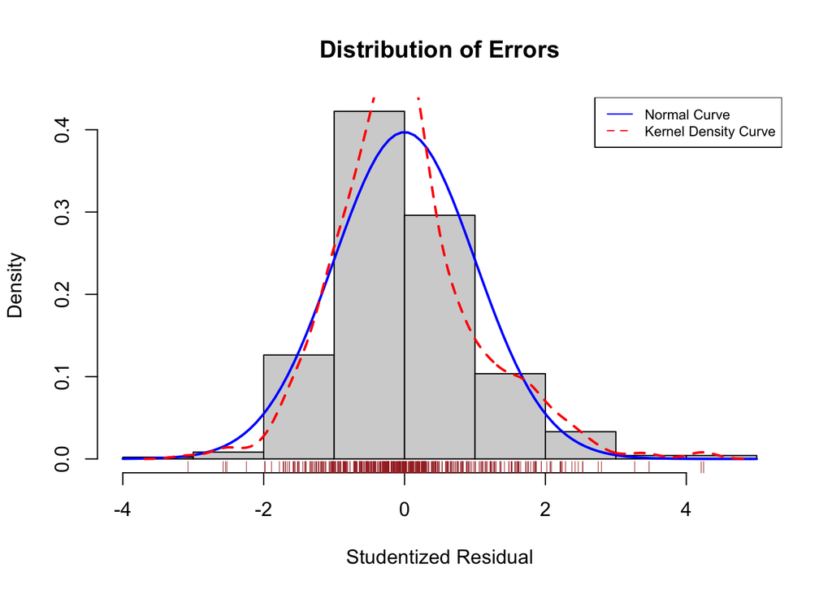

Se observa que mis datos son mas extremos que mi normal.

## CONTRASTE DE NORMALIDAD DE JARQUE-BERA:

```r
vResid=resid(model3)
jbTest(vResid)
```

```
##
## Title:
##  Jarque - Bera Normality Test
##
## Test Results:
##   PARAMETER:
##     Sample Size: 483
##   STATISTIC:
##     LM: 79.219
##     ALM: 81.705
##   P VALUE:
##     ALM p-value: < 2.2e-16
##     Asymptotic: < 2.2e-16
##
## Description:
##  Wed Oct 28 21:18:28 2020 by user:
```

## SHAPIRO-WILK TEST:

```r
shapiro.test(vResid)
```

```
##
##  Shapiro-Wilk normality test
##
## data:  vResid
## W = 0.96773, p-value = 8.078e-09
```

Como p-valor es menor que 0.05 se rechaza la hipotesis nula de que sigue una distribucion normal.

## LINEALIDAD: Componentes o Gráficos de residuos parciales

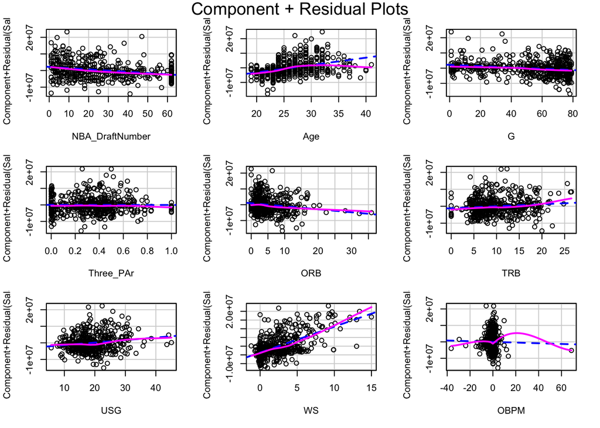

## VARIANZA CONSTANTE.Homocedasticidad

```r
ncvTest(model3)
```

```
## Non-constant Variance Score Test
## Variance formula: ~ fitted.values
## Chisquare = 92.96626, Df = 1, p = < 2.22e-16
```

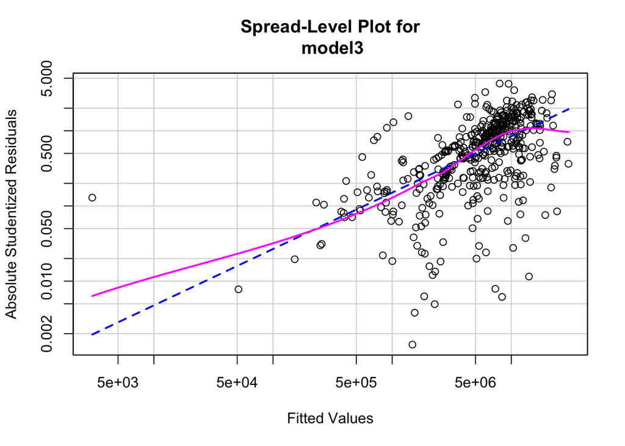

```
##
## Suggested power transformation:  0.2500741
```

```r
spreadLevelPlot(model3)
```

Con un modelo explicativo esto es útil, pero no para un modelo predictivo ya que me he dado cuenta de que hay datos que no son homogéneos, por lo que tengo que hacer modelos distintos

## VALIDACION GLOBAL:

```r
gvmodel <- gvlma(model3)
summary(gvmodel)
```

```
##
## Call:
## lm(formula = Salary ~ NBA_DraftNumber + Age + G + Three_PAr +
##     ORB + TRB + USG + WS + OBPM, data = nba)
##
## Residuals:
##       Min        1Q    Median        3Q       Max
## -15718763  -3237174   -476591   2291904  21784544
##
## Coefficients:
##                 Estimate Std. Error t value Pr(>|t|)
## (Intercept)     -9067896    2272616  -3.990 7.65e-05 ***
## NBA_DraftNumber   -74902      12677  -5.909 6.61e-09 ***
## Age               506275      57353   8.827  < 2e-16 ***
## G                 -42704      13271  -3.218  0.00138 **
## Three_PAr         -64346    1373344  -0.047  0.96265
## ORB              -191298      94213  -2.030  0.04287 *
## TRB               117868      87748   1.343  0.17983
## USG               151380      46254   3.273  0.00114 **
## WS               1487095     136388  10.903  < 2e-16 ***
## OBPM              -20898      55565  -0.376  0.70701
## ---
## Signif. codes:  0 '***' 0.001 '**' 0.01 '*' 0.05 '.' 0.1 ' ' 1
##
## Residual standard error: 5293000 on 473 degrees of freedom
## Multiple R-squared:  0.4977, Adjusted R-squared:  0.4881
## F-statistic: 52.07 on 9 and 473 DF,  p-value: < 2.2e-16
##
##
## ASSESSMENT OF THE LINEAR MODEL ASSUMPTIONS
## USING THE GLOBAL TEST ON 4 DEGREES-OF-FREEDOM:
## Level of Significance =  0.05
##
## Call:
##  gvlma(x = model3)
##
##                      Value   p-value                   Decision
## Global Stat        86.1424 0.000e+00 Assumptions NOT satisfied!
## Skewness           38.9659 4.313e-10 Assumptions NOT satisfied!
## Kurtosis           40.2534 2.231e-10 Assumptions NOT satisfied!
## Link Function       6.2771 1.223e-02 Assumptions NOT satisfied!
## Heteroscedasticity  0.6461 4.215e-01    Assumptions acceptable.
```

Hay problemas de simetria y de curtosis por lo que se rechaza la validación global.

## OUTLIERS:

### Valores atipicos:

```r
outlierTest(model3)
```

```
##     rstudent unadjusted p-value Bonferroni p
## 326 4.246533         2.6158e-05     0.012634
## 112 4.212085         3.0315e-05     0.014642
```

Nos identifica dos valores atípicos, el 326 y 112.

### Valores extremos:

Para identificarlos se usa el hat statistic.

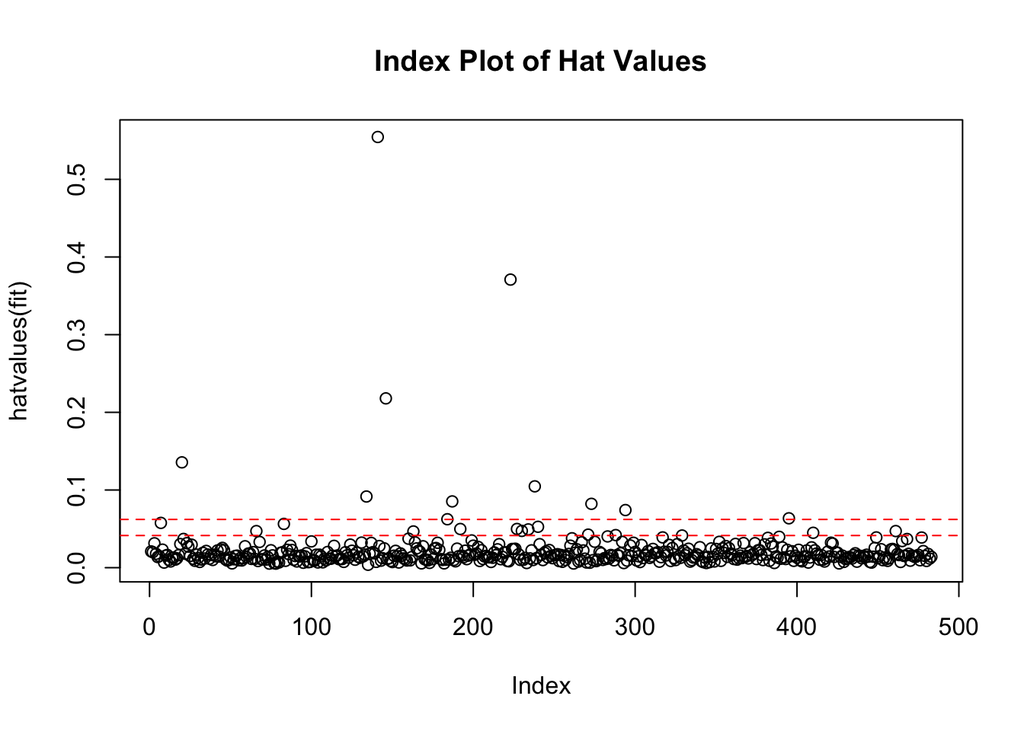

```
## integer(0)
```

```r
hat.plot <- function(fit) {
  p <- length(coefficients(fit))
  n <- length(fitted(fit))
  plot(hatvalues(fit), main="Index Plot of Hat Values")
  abline(h=c(2,3)*p/n, col="red", lty=2)
  identify(1:n, hatvalues(fit), names(hatvalues(fit)))
}
hat.plot(model3)
```

Aparecen valores por encima de la segunda linea, esos son los valores extremos.

### Valores influyentes: Distancia de Cook.

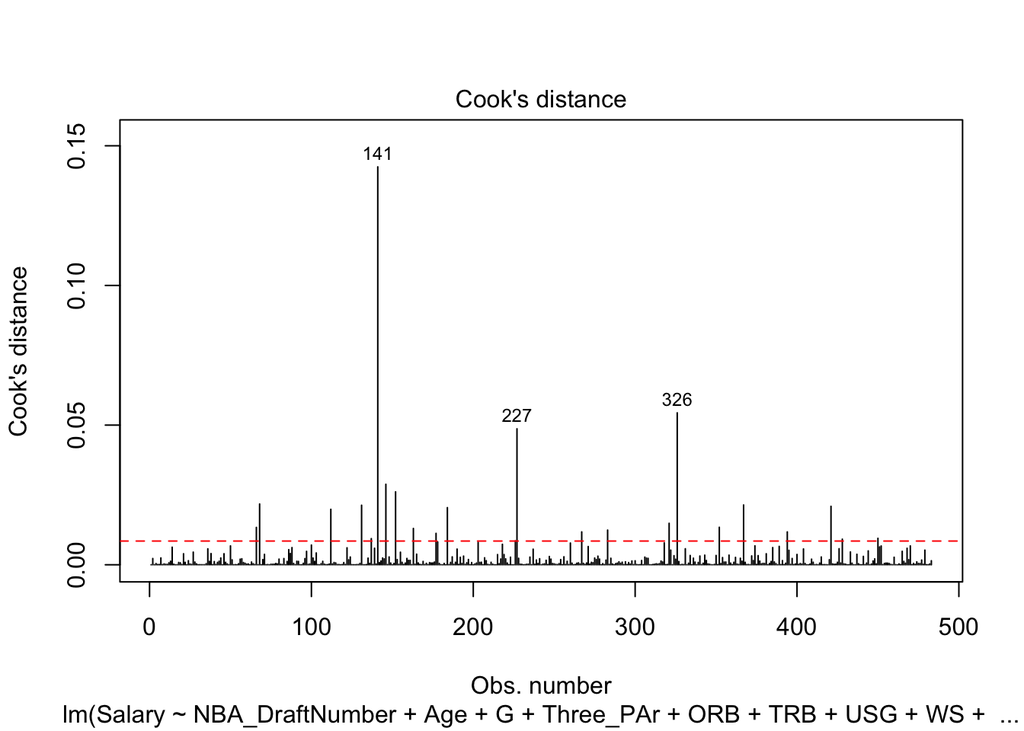

```r
cutoff <- 4/(nrow(nba)-length(model3$coefficients)-2)
plot(model3, which=4, cook.levels=cutoff)
abline(h=cutoff, lty=2, col="red")
```

Otra forma de identificar los valores influyentes es a traves de graficos added variable

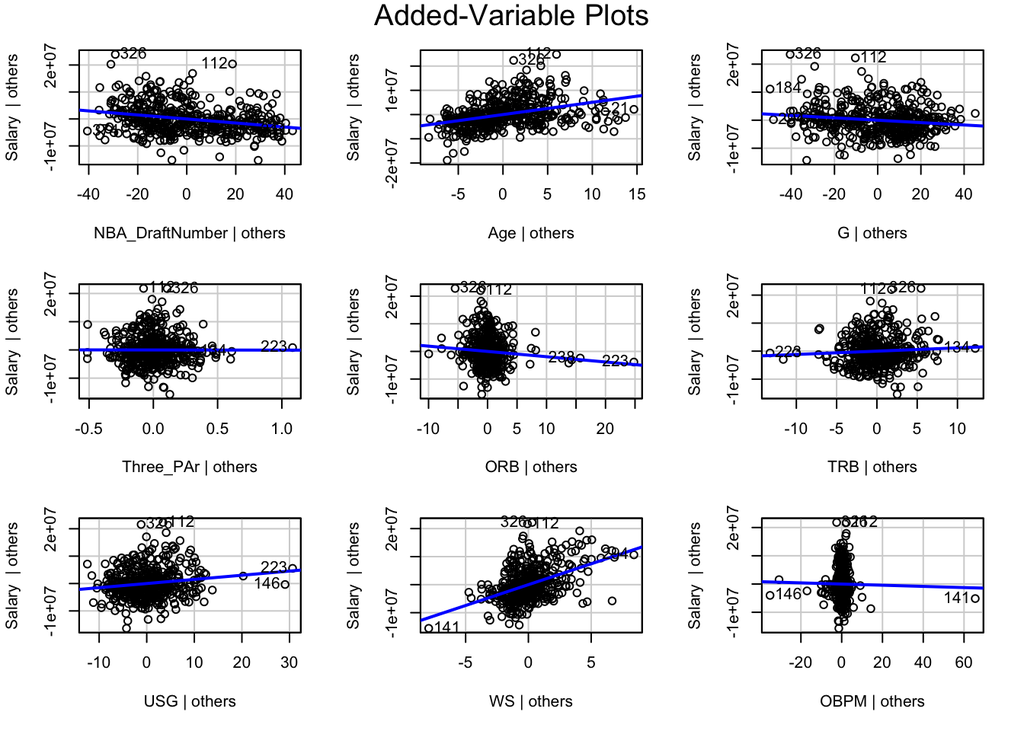

```r
avPlots(model3, ask=FALSE, id.method="identify")
```

Represento el influence plot:

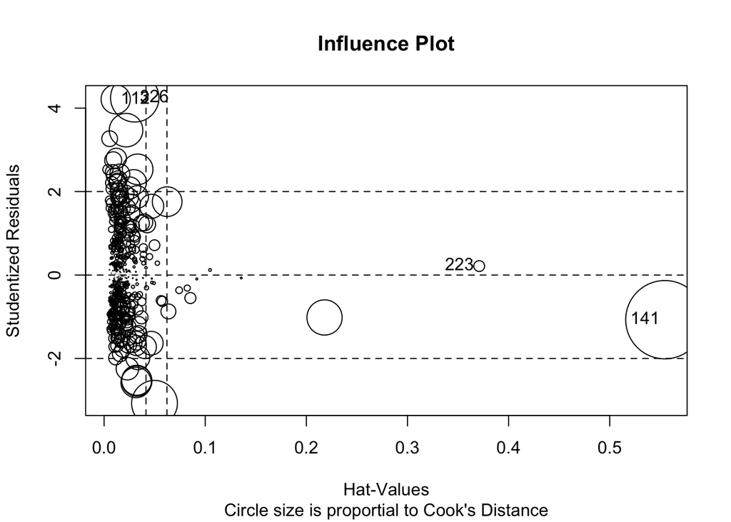

```
##        StudRes        Hat       CookD
## 112  4.2120847 0.01145403 0.019854070
## 141 -1.0700388 0.55448887 0.142462404
## 223  0.2146606 0.37088728 0.002722043
## 326  4.2465330 0.03030578 0.054399562
```

**Los análisis muestran varias observaciones influyentes (posición 141 y 223) que exceden los límites de preocupación para los valores de Leverages o Distancia Cook. Estudios más exhaustivos consistirían en rehacer el modelo sin las observaciones y ver el impacto. Cuanto más lejos esten es que son mas extremos.**